# FigureYa207Randomization

# Academic Citation

If you use this code in your work or research, we kindly request that you cite our publication:

Xiaofan Lu, et al. (2025). FigureYa: A Standardized Visualization Framework for Enhancing Biomedical Data Interpretation and Research Efficiency. iMetaMed. https://doi.org/10.1002/imm3.70005

# 需求描述

# Demand description

我想实现文章Figure 1B的计算方法，用Randomization test来检测多个差异基因的分布情况，属于差异基因的横向分析，从不同的角度来认识差异基因。

I would like to crowdsource the computational method for Figure 1B in the article, which uses a Randomization test to examine the distribution of multiple differentially expressed genes. This belongs to the horizontal analysis of differentially expressed genes, providing different perspectives to understand them.

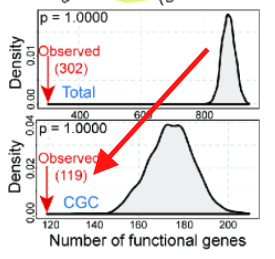

出自：https://www.aging-us.com/article/102766/text

图1. 胆管癌（在TCGA中命名为CHOL）异常表达基因及其在不同癌症类型中的表达模式。(B) 针对筛选出的异常基因，展示了相关功能基因（主要包括必需基因、CGC、癌基因等）的分布情况。**与同等数量正常表达基因的随机结果相比**，被鉴定为功能基因的异常基因数量更少。

**随机化检验**

为确定特定基因分类检测频率的显著性，我们进行了随机化检验：**随机选取数量相等的正常表达基因**。该过程重复1,000次（显著性根据出现比例估算），用于评估**观察到的平均相关性值是否高于真实平均相关性**。

Source: https://www.aging-us.com/article/102766/text

Figure 1. Abnormally expressed genes in CCA (named CHOL in TCGA) and their expression patterns across diverse cancer types. (B) For screened abnormal genes, distributions of associated functional genes (mainly including essential gene, CGC, oncogene, etc) are presented. **Compared with random result in the equal number of normally expressed genes**, fewer abnormal genes are identified as functional genes.

**Randomization test**

To determine the significance of a detected frequency of special gene classification, we performed a **randomization test by randomly selecting normally expressed genes with equal numbers**. This procedure was repeated 1,000 times (the significance was estimated based on the proportion of times), and was used to estimate **whether the average correlation values observed were higher than the real average correlation**.

# 应用场景

# Application scenarios

Randomization test来检验差异表达基因的模式是否是随机出现的。

灵活运用，不仅限于差异表达基因的检验，任何感兴趣的基因集都可以作为检验的对象。

Randomization test is used to examine whether the patterns of differentially expressed genes (DEGs) occur randomly.

This method is flexible and versatile, not limited to testing DEGs—any gene set of interest can serve as the subject of analysis.

> 注意：以下为个人见解 Note: The following are my personal opinions

FigureYa156enrichSimulation的富集检验零假设为两者分布是否一致，当p>0.05时，小概率事件发生了，因而接受原假设，认为分布没有统计学差异，故没有富集；

这里的随机化检验，使用的方法和富集检验如出一辙，均为重抽样计算概率分布密度，但其零假设的关键是基因分类标签的可交换性，或者说是否是DEG与基因的分类标签是无关的（参考：https://www.uvm.edu/~statdhtx/StatPages/Randomization%20Tests/null_hypotheses.html）

实际上原文作者也可以采用富集检验，来证明DEG是与CGC是弱关联（低富集），但是这里使用随机化检验，证明DEG的基因名的与CGC的标签无关。

The enrichment test in FigureYa156enrichSimulation has the null hypothesis that the distributions of the two are consistent. When p>0.05, a small probability event occurs, thus accepting the null hypothesis and concluding there is no statistically significant difference in distribution, hence no enrichment;

The randomization test used here employs a method virtually identical to the enrichment test, both involving resampling to calculate probability distribution density. However, the key to its null hypothesis lies in the exchangeability of gene classification labels, or in other words, whether being a DEG is independent of gene classification labels (reference: https://www.uvm.edu/~statdhtx/StatPages/Randomization%20Tests/null_hypotheses.html).

The original article authors could have actually used an enrichment test to demonstrate that DEGs are weakly associated with CGC (low enrichment). But here they used a randomization test to prove that DEG gene identities are unrelated to CGC labels.

# 环境设置

# Environment Setup

```r
source("install_dependencies.R")
```

```
## Starting R package installation...
## ===========================================
##
## Installing CRAN packages...
## Package already installed: shape
##
## Installing Bioconductor packages...
## Package already installed: DESeq2
## Package already installed: TCGAbiolinks
##
## ===========================================
## Package installation completed!
## You can now run your R scripts in this directory.
```

```r
library(TCGAbiolinks)
library(DESeq2)
library(shape)

# 显示英文报错信息
# Show English error messages
Sys.setenv(LANGUAGE = "en")

# 禁止chr转成factor
# Prevent character-to-factor conversion
options(stringsAsFactors = FALSE)
```

# 输入文件的获得

# Obtaining Input Files

如果你的数据已经处理成easy_input_diff.csv和easy_input_func_genes.txt，就可以跳过这步，直接进入“输入文件”。

If your data has already been processed into easy_input_diff.csv and easy_input_func_genes.txt, you can skip this step and proceed directly to the “Input Files” section.

## 用TCGAbiolinks下载表达数据和样本信息。

## Download expression data and sample information using TCGAbiolinks

```r
## 下载TCGA-CHOL原始count数据
## Download raw count data for TCGA-CHOL
expquery <- GDCquery(project = "TCGA-CHOL",
                     data.category = "Transcriptome Profiling",
                     data.type = "Gene Expression Quantification",
                     workflow.type = "STAR - Counts"
)
```

```
## o GDCquery: Searching in GDC database
```

```
## Genome of reference: hg38
```

```
## oo Accessing GDC. This might take a while...
```

```
## ooo Project: TCGA-CHOL
```

```
## oo Filtering results
```

```
## ooo By data.type
```

```
## ooo By workflow.type
```

```
## oo Checking data
```

```
## ooo Checking if there are duplicated cases
```

```
## ooo Checking if there are results for the query
```

```
## o Preparing output
```

```r
GDCdownload(expquery,directory = "GDCdata")
```

```
## Of the 44 files for download 44 already exist.
```

```
## All samples have been already downloaded
```

```r
expquery2 <- GDCprepare(expquery,directory = "GDCdata",summarizedExperiment = T)
```

```
## Starting to add information to samples
```

```
##  => Add clinical information to samples
```

```
##  => Adding TCGA molecular information from marker papers
```

```
##  => Information will have prefix 'paper_'
```

```
## chol subtype information from:doi:10.1016/j.celrep.2017.02.033
```

```
## Available assays in SummarizedExperiment :
##   => unstranded
##   => stranded_first
##   => stranded_second
##   => tpm_unstrand
##   => fpkm_unstrand
##   => fpkm_uq_unstrand
```

```r
expMatrix <- TCGAanalyze_Preprocessing(expquery2)
```

```
## Number of outliers: 0
```

```r
colnames(expMatrix) <- substr(colnames(expMatrix), start = 1,stop = 15)

## 取正常样本(样本编号以11结尾)
## Extract normal samples (sample IDs ending with 11)
normsamples <- colnames(expMatrix)[which(substr(colnames(expMatrix),14,15) == "11")]

## 取肿瘤样本(样本编号以01结尾)
## Extract tumor samples (sample IDs ending with 01)
tumorsamples <- colnames(expMatrix)[which(substr(colnames(expMatrix),14,15) == "01")]

# 表达数据处理
# Expression data processing
expMatrix <- expMatrix[,c(tumorsamples,normsamples)]
expMatrix <- as.data.frame(expMatrix[rowSums(expMatrix) > 0,])
expMatrix[1:3,1:3]
```

```
##                    TCGA-3X-AAV9-01 TCGA-3X-AAVA-01 TCGA-3X-AAVB-01
## ENSG00000000003.15            3350            4252            1997
## ENSG00000000005.6                1               1               2
## ENSG00000000419.13            1802            1251            1359
```

```r
# 样本信息
# Sample information
saminfo <- data.frame("Type" = rep(c("tumor","normal"),c(length(tumorsamples),length(normsamples))),
                      "SampleID" = c(tumorsamples,normsamples),
                      stringsAsFactors = FALSE)

# TCGA的表达矩阵用的是ensembl ID，需要转换为gene symbol
# 读取注释匹配文件，用于把表达矩阵中的ID转换为gene symbol
# TCGA expression matrix uses ensembl ID, need to convert to gene symbol
# Read annotation file for ID conversion
Ginfo <- read.table("overlapTable27.txt",sep = "\t",row.names = 1,check.names = F,stringsAsFactors = F,header = T)
head(Ginfo)
```

```
##                            gene_id unqlen          simple genename
## ENSG00000000003 ENSG00000000003.14   4535 ENSG00000000003   TSPAN6
## ENSG00000000005  ENSG00000000005.5   1610 ENSG00000000005     TNMD
## ENSG00000000419 ENSG00000000419.12   1207 ENSG00000000419     DPM1
## ENSG00000000457 ENSG00000000457.13   6883 ENSG00000000457    SCYL3
## ENSG00000000460 ENSG00000000460.16   5967 ENSG00000000460 C1ORF112
## ENSG00000000938 ENSG00000000938.12   3474 ENSG00000000938      FGR
##                       genetype
## ENSG00000000003 protein_coding
## ENSG00000000005 protein_coding
## ENSG00000000419 protein_coding
## ENSG00000000457 protein_coding
## ENSG00000000460 protein_coding
## ENSG00000000938 protein_coding
```

```r
rownames(Ginfo) <- Ginfo$gene_id
comgene <- intersect(rownames(expMatrix),rownames(Ginfo))
count <- as.data.frame(expMatrix)[comgene,]; Ginfo <- Ginfo[comgene,]
count$gene <- Ginfo$genename; count <- count[!duplicated(count$gene),]; Ginfo <- Ginfo[rownames(count),]; rownames(count) <- count$gene; count <- count[,-ncol(count)] # 去重复
count[1:3,1:3]
```

```
##       TCGA-3X-AAV9-01 TCGA-3X-AAVA-01 TCGA-3X-AAVB-01
## NFYA             1042            1495            1520
## MYH16              75              19              60
## LAP3             3367            2217            3456
```

```r
# 把处理好的表达矩阵保存到文件，可用于更多后续分析
# Save processed expression matrix for downstream analysis
write.csv(count, "TCGA_CHOL_Count.txt", quote=F, row.names=T, col.names = NA)
```

## 差异表达分析

## Differential Expression Analysis

这里用DESeq2，还可以用limma、edgeR等方法，可参考FigureYa118MulticlassDESeq2、FigureYa119Multiclasslimma、FigureYa120MulticlassedgeR。

芯片数据从下载到差异分析可参考FigureYa59Plus_GEO2DEG

Here we use DESeq2, but limma and edgeR can also be used. Refer to FigureYa118MulticlassDESeq2, FigureYa119Multiclasslimma, FigureYa120MulticlassedgeR.

For microarray data processing from download to differential analysis, see FigureYa59Plus_GEO2DEG

```r
# 创建DESeq2数据集对象
# Create DESeq2 dataset object
dds <- DESeqDataSetFromMatrix(countData = count,
                              colData = saminfo,
                              design = as.formula("~ Type"))
# 设置比较基准为正常样本
# Set reference level to normal samples
dds$Type <- relevel(dds$Type,ref = "normal")

# 运行DESeq2差异表达分析
# Run DESeq2 differential expression analysis
dds <- DESeq(dds)
```

```
## -- replacing outliers and refitting for 1269 genes
## -- DESeq argument 'minReplicatesForReplace' = 7
## -- original counts are preserved in counts(dds)
```

```r
# 提取分析结果(肿瘤vs正常)
# Extract results (tumor vs normal)
resData <- as.data.frame(results(dds, contrast = c("Type","tumor","normal")))

# 添加基因ID列
# Add gene ID column
resData$id <- rownames(resData)

# 选择需要保留的列
# Select columns to keep
resData <- resData[,c("id","baseMean","log2FoldChange","lfcSE","stat","pvalue","padj")]

# 输出差异分析结果
# Output differential analysis results
write.csv(resData, file = "easy_input_diff.csv", row.names = FALSE, quote = FALSE)
```

## 功能基因集

## Functional Gene Sets

例文把差异表达基因分别跟5种functional genes取交集，并检验差异表达基因的模式是否是随机出现的。

这里以CGC为例，即Cancer Gene Census，`Census_allSun Oct 4 05_23_42 2020.csv`，若使用请先注册：https://cancer.sanger.ac.uk/census#cl_search。

其他4种functional genes的计算方法是一样的。

The example intersects differentially expressed genes with five types of functional genes and tests whether the patterns of differentially expressed genes occur randomly.

Here, we use CGC (Cancer Gene Census) as an example (Census_allSun Oct 4 05_23_42 2020.csv). Registration is required before use: https://cancer.sanger.ac.uk/census#cl_search.

The calculation methods for the other four functional gene sets are identical.

```r
# 从CSV文件加载CGC数据
# Load CGC data from CSV file
cgc <- read.csv("Census_allSun Oct  4 05_23_42 2020.csv",row.names = NULL,check.names = F,stringsAsFactors = F,header = T)

# 查看数据前几行
# Check first few rows of the data
head(cgc)
```

```
##   Gene Symbol                                                   Name
## 1        A1CF                         APOBEC1 complementation factor
## 2        ABI1                                       abl-interactor 1
## 3        ABL1 v-abl Abelson murine leukemia viral oncogene homolog 1
## 4        ABL2         c-abl oncogene 2, non-receptor tyrosine kinase
## 5       ACKR3                          atypical chemokine receptor 3
## 6       ACSL3         acyl-CoA synthetase long-chain family member 3
##   Entrez GeneId       Genome Location Tier Hallmark Chr Band Somatic Germline
## 1         29974  10:50799421-50885675    2             11.23     yes
## 2         10006  10:26746593-26860935    1      Yes    12.10     yes
## 3            25 9:130713946-130885683    1      Yes    34.12     yes
## 4            27 1:179099327-179229601    1             25.20     yes
## 5         57007 2:236569641-236582358    1      Yes    37.30     yes
## 6          2181 2:222860934-222944639    1      Yes    36.10     yes
##   Tumour Types(Somatic) Tumour Types(Germline) Cancer Syndrome Tissue Type
```

[output cut: 27 more lines]

```r
# 查看数据集行数
# Check number of rows in dataset
nrow(cgc)
```

```
## [1] 723
```

```r
# 提取并保存基因符号，只需要第一列"Gene Symbol"，保存为文本文件以便后续分析
# Extract and save gene symbols. Only need the first column "Gene Symbol". Save as text file for downstream analysis
write.table(cgc$`Gene Symbol`, "easy_input_func_genes.txt", quote = F, row.names = F, col.names = "GeneSymbol")
```

# 输入文件

# Input Files

easy_input_diff.csv，差异分析结果。这里用到log2FoldChange和padj两列，用于筛选差异基因。也可以直接提供候选基因集degs和背景negs。这里的degs用的是差异表达基因，还可以是任何你想要检验的基因集。

easy_input_func_genes.txt，function genes。实际使用时可以替换为你感兴趣的基因集，例如已知的参与某个调控过程的基因集。

easy_input_diff.csv - Differential analysis results. This file uses the log2FoldChange and padj columns for filtering differentially expressed genes (DEGs). Alternatively, you may directly provide a candidate gene set (degs) and a background set (negs). Here, degs refers to differentially expressed genes, but it can be replaced with any gene set you wish to test.

easy_input_func_genes.txt - Functional genes. In practice, this can be replaced with any gene set of interest, such as a known set of genes involved in a specific regulatory process.

```r
# 加载差异分析结果
# Load differential expression analysis results
resData <- read.csv("easy_input_diff.csv", header = T)

# 查看数据前几行
# Display first few rows of the data
head(resData)
```

```
##        id   baseMean log2FoldChange     lfcSE       stat       pvalue
## 1    NFYA 1062.53471      0.2575629 0.1924126  1.3385965 1.807021e-01
## 2   MYH16   17.33073      3.0539419 0.7498678  4.0726402 4.648320e-05
## 3    LAP3 4567.80265     -1.4586631 0.2108723 -6.9172827 4.603888e-12
## 4  MAD1L1   16.09179     -0.3100612 0.4964770 -0.6245228 5.322843e-01
## 5  KLHL13  146.03947     -0.9382948 0.4740638 -1.9792586 4.778690e-02
## 6 CYP26B1  350.77537      2.6181405 0.7214755  3.6288695 2.846651e-04
##           padj
## 1 3.214142e-01
## 2 3.369476e-04
## 3 1.430747e-10
## 4 6.721751e-01
## 5 1.198628e-01
## 6 1.682175e-03
```

```r
# 加载功能基因集
# Load functional gene set
cgc <- read.table("easy_input_func_genes.txt", header = T)

# 查看功能基因前几行
# Display first few functional genes
head(cgc)
```

```
##   GeneSymbol
## 1       A1CF
## 2       ABI1
## 3       ABL1
## 4       ABL2
## 5      ACKR3
## 6      ACSL3
```